# Predicting Boston Housing Prices

### *Gary Ng*

This project was completed in conjunction with the "Model Evaluation and Validation" module of Udacity's Nanodegree Program for Machine Learning Engineer. In this project, we learnt to apply simple machine learning techniques using NumPy and Scikit-Learn, analyze various learning performance plots for variance and bias, and evaluate a model’s performance on unseen data using previous data.

A description of the dataset can be found [here](https://archive.ics.uci.edu/ml/datasets/Housing), which is provided by the **UCI Machine Learning Repository**.

```python
# Import key libraries
import numpy as np
import pandas as pd
import matplotlib.pyplot as pl
from sklearn import datasets
from sklearn.tree import DecisionTreeRegressor

# Make matplotlib show our plots inline
%matplotlib inline

# Create our client's feature set for which we will be predicting a selling price
CLIENT_FEATURES = [[11.95, 0.00, 18.100, 0, 0.6590, 5.6090, 90.00, 1.385, 24, 680.0, 20.20, 332.09, 12.13]]

# Load the Boston Housing dataset into the city_data variable
city_data = datasets.load_boston()

# Initialize the housing prices and housing features
housing_prices = city_data.target
housing_features = city_data.data
```

# Statistical Analysis and Data Exploration

In this first section of the project, you will quickly investigate a few basic statistics about the dataset you are working with. In addition, you'll look at the client's feature set in `CLIENT_FEATURES` and see how this particular sample relates to the features of the dataset. Familiarizing yourself with the data through an explorative process is a fundamental practice to help you better understand your results.

## Step 1

In the code block below, use the imported `numpy` library to calculate the requested statistics. Be sure to execute the code block each time to test if your implementation is working successfully. The print statements will show the statistics you calculate!

```python
# Number of houses in the dataset
total_houses = housing_prices.shape[0]

# Number of features in the dataset
total_features = housing_features.shape[1]

# Minimum housing value in the dataset
minimum_price = np.min(housing_prices)

# Maximum housing value in the dataset
maximum_price = np.max(housing_prices)

# Mean house value of the dataset
mean_price = np.mean(housing_prices)

# Median house value of the dataset
median_price = np.median(housing_prices)

# Standard deviation of housing values of the dataset
std_dev = np.std(housing_prices)

# Show the calculated statistics
print "Boston Housing dataset statistics (in $1000's):\n"
print "Total number of houses:", str(total_houses)
print "Total number of features:", str(total_features)
print "Minimum house price:", minimum_price
print "Maximum house price:", maximum_price
print "Mean house price: {0:.3f}".format(mean_price)
print "Median house price:", median_price
print "Standard deviation of house price: {0:.3f}".format(std_dev)
```

```
Boston Housing dataset statistics (in $1000's):

Total number of houses: 506
Total number of features: 13
Minimum house price: 5.0
Maximum house price: 50.0
Mean house price: 22.533
Median house price: 21.2
Standard deviation of house price: 9.188
```

## Question 1

*Of the features available for each data point, choose three that you feel are significant and give a brief description for each of what they measure.*

**Answer:**

Of the 13 features in the dataset, I suspect the following three are most likely strong predictors of housing prices:

- CRIM: per capita crime rate by town *(higher the crime rate, lower the housing prices)*
- PTRATIO: pupil-teacher ratio by town *(higher the ratio, lower the quality of education, and consequently housing prices)*
- LSTAT: % lower status of the population *(higher the percentage of lower-status folks, poorer the neighborhood, and consequently lower housing prices)*

## Question 2

*Using your client's feature set `CLIENT_FEATURES`, which values correspond with the features you've chosen above?*

```python
CLIENT_FEATURES_LABELED = pd.Series(CLIENT_FEATURES[0], index = city_data.feature_names)
print CLIENT_FEATURES_LABELED
```

```
CRIM        11.950
ZN           0.000
INDUS       18.100
CHAS         0.000
NOX          0.659
RM           5.609
AGE         90.000
DIS          1.385
RAD         24.000
TAX        680.000
PTRATIO     20.200
B          332.090
LSTAT       12.130
dtype: float64
```

**Answer:** The client's house is associated with CRIM of 11.95, PTRATIO of 20.2, and LSTAT of 12.13.

# Evaluating Model Performance

In this second section of the project, you will begin to develop the tools necessary for a model to make a prediction. Being able to accurately evaluate each model's performance through the use of these tools helps to greatly reinforce the confidence in your predictions.

## Step 2

In the code block below, you will need to implement code so that the `shuffle_split_data` function does the following:

- Randomly shuffle the input data `X` and target labels (housing values) `y`.
- Split the data into training and testing subsets, holding 30% of the data for testing.

```python
from sklearn import cross_validation

def shuffle_split_data(X, y):
    """ Shuffles and splits data into 70% training and 30% testing subsets,
        then returns the training and testing subsets. """

    # Shuffle and split the data
    X_train, X_test, y_train, y_test = cross_validation.train_test_split(X, y, test_size=0.3, random_state=88)

    # Return the training and testing data subsets
    return X_train, y_train, X_test, y_test

# Test shuffle_split_data
try:
    X_train, y_train, X_test, y_test = shuffle_split_data(housing_features, housing_prices)
    print "Successfully shuffled and split the data!"
except:
    print "Something went wrong with shuffling and splitting the data."
```

```
Successfully shuffled and split the data!
```

## Question 3

*Why do we split the data into training and testing subsets for our model?*

**Answer:** We split the data into training and testing subsets to estimate the performance of our model when applied to unseen data. In addition, it also serves as a check on overfitting.

## Step 3

In the code block below, you will need to implement code so that the `performance_metric` function does the following:

- Perform a total error calculation between the true values of the `y` labels `y_true` and the predicted values of the `y` labels `y_predict`.

```python
from sklearn.metrics import mean_absolute_error

def performance_metric(y_true, y_predict):
    """ Calculates and returns the total error between true and predicted values
        based on a performance metric chosen by the student. """

    error = mean_absolute_error(y_true, y_predict)
    return error


# Test performance_metric
try:
    total_error = performance_metric(y_train, y_train)
    print "Successfully performed a metric calculation!"
except:
    print "Something went wrong with performing a metric calculation."
```

```
Successfully performed a metric calculation!
```

## Question 4

*Which performance metric below did you find was most appropriate for predicting housing prices and analyzing the total error. Why?*

- *Accuracy*
- *Precision*
- *Recall*
- *F1 Score*
- *Mean Squared Error (MSE)*
- *Mean Absolute Error (MAE)*

**Answer:** Since this was a regression rather than a classification problem, only Mean Squared Error (MSE) and Mean Absolute Error (MAE) are appropriate performance metrics for our model. Of the two, I chose MAE for its intuitive interpretation. Moreover, there isn't a strong justification for why we might need to punish outliers (using MSE) in this case.

## Step 4 (Final Step)

```python
from sklearn.metrics import make_scorer
from sklearn.grid_search import GridSearchCV

def fit_model(X, y):
    """ Tunes a decision tree regressor model using GridSearchCV on the input data X
        and target labels y and returns this optimal model. """

    # Create a decision tree regressor object
    regressor = DecisionTreeRegressor()

    # Set up the parameters we wish to tune
    parameters = {'max_depth':(1,2,3,4,5,6,7,8,9,10)}

    # Make an appropriate scoring function
    scoring_function = make_scorer(mean_absolute_error, greater_is_better=False)

    # Make the GridSearchCV object
    reg = GridSearchCV(estimator = regressor, param_grid = parameters, scoring = scoring_function)

    # Fit the learner to the dataset to obtain the optimal model with tuned parameters
    reg.fit(X, y)

    # Return the optimal model
    return reg

# Test fit_model
try:
    reg = fit_model(housing_features, housing_prices)
    print "Successfully fit a model!"
except:
    print "Something went wrong with fitting a model."
```

```
Successfully fit a model!
```

## Question 5

*What is the grid search algorithm and when is it applicable?*

**Answer:** A grid search algorithm is one that systematically works through multiple combinations of parameter tunes, cross-validating as it goes to determine which tune provides the best performance. They are generally applicable in most situations, but especially helpful when we have many options for various parameters and there is not an obvious combination to use based on past experience or contextual knowledge.

## Question 6

*What is cross-validation, and how is it performed on a model? Why would cross-validation be helpful when using grid search?*

**Answer:** Cross-validation is a method to maximize the use of sample data for both training and testing purposes. In a standard K-fold cross-validation, the data set is divided into K folds. The model is then trained K times, each time using K-1 of the folds, and then tested on the remaining fold. That way, each data point is used for both training and testing, and we likely obtain more accurate and stable results. Similarly, we can expect to greater confidence in the accuracy of our tuned parameters from grid search by using cross-validation. In the absence of cross-validation, our tuned parameters would be subject to greater variability depending on our choice of one set of training and testing data.

# Analyzing Model Performance

In this third section of the project, you'll take a look at several models' learning and testing error rates on various subsets of training data. Additionally, you'll investigate one particular algorithm with an increasing `max_depth` parameter on the full training set to observe how model complexity affects learning and testing errors. Graphing your model's performance based on varying criteria can be beneficial in the analysis process, such as visualizing behavior that may not have been apparent from the results alone.

```python
def learning_curves(X_train, y_train, X_test, y_test):
    """ Calculates the performance of several models with varying sizes of training data.
        The learning and testing error rates for each model are then plotted. """

    print "Creating learning curve graphs for max_depths of 1, 3, 6, and 10. . ."

    # Create the figure window
    fig = pl.figure(figsize=(10,8))

    # We will vary the training set size so that we have 50 different sizes
    sizes = np.round(np.linspace(1, len(X_train), 50))
    train_err = np.zeros(len(sizes))
    test_err = np.zeros(len(sizes))

    # Create four different models based on max_depth
    for k, depth in enumerate([1,3,6,10]):

        for i, s in enumerate(sizes):

            # Setup a decision tree regressor so that it learns a tree with max_depth = depth
            regressor = DecisionTreeRegressor(max_depth = depth)

            # Fit the learner to the training data
            regressor.fit(X_train[:s], y_train[:s])

            # Find the performance on the training set
            train_err[i] = performance_metric(y_train[:s], regressor.predict(X_train[:s]))

            # Find the performance on the testing set
            test_err[i] = performance_metric(y_test, regressor.predict(X_test))

        # Subplot the learning curve graph
        ax = fig.add_subplot(2, 2, k+1)
        ax.plot(sizes, test_err, lw = 2, label = 'Testing Error')
        ax.plot(sizes, train_err, lw = 2, label = 'Training Error')
        ax.legend()
        ax.set_title('max_depth = %s'%(depth))
        ax.set_xlabel('Number of Data Points in Training Set')
        ax.set_ylabel('Total Error')
        ax.set_xlim([0, len(X_train)])

    # Visual aesthetics
    fig.suptitle('Decision Tree Regressor Learning Performances', fontsize=18, y=1.03)
    fig.tight_layout()
    fig.show()
```

```
Creating learning curve graphs for max_depths of 1, 3, 6, and 10. . .
```

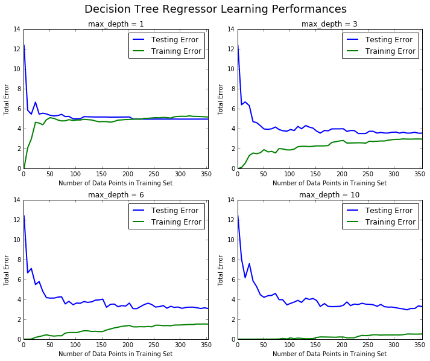

```python
learning_curves(X_train, y_train, X_test, y_test)
```

## Question 7

*Choose one of the learning curve graphs that are created above. What is the max depth for the chosen model? As the size of the training set increases, what happens to the training error? What happens to the testing error?*

**Answer:** Take for instance the learning curve graph for max depth = 3. As the size of the training set increases, training and testing errors begin to converge. Training error increases gradually with more data to fit and trade-offs to be made, while testing error decreases as the model becomes more accurate, albeit plateauing off pretty quickly at around N=50.

## Question 8

*Look at the learning curve graphs for the model with a max depth of 1 and a max depth of 10. When the model is using the full training set, does it suffer from high bias or high variance when the max depth is 1? What about when the max depth is 10?*

**Answer:** When using the full training set, the model with max depth = 1 suffers from high bias as the testing and training errors converge at a high value, indicating that the model cannot represent the underlying relationship well no matter how much data is being fed. On the other hand, the model suffers from high variance when max depth = 10, as we see a large gap between testing and training errors even when the full training set is used.

```python
def model_complexity(X_train, y_train, X_test, y_test):
    """ Calculates the performance of the model as model complexity increases.
        The learning and testing errors rates are then plotted. """

    print "Creating a model complexity graph. . . "

    # We will vary the max_depth of a decision tree model from 1 to 14
    max_depth = np.arange(1, 14)
    train_err = np.zeros(len(max_depth))
    test_err = np.zeros(len(max_depth))

    for i, d in enumerate(max_depth):
        # Setup a Decision Tree Regressor so that it learns a tree with depth d
        regressor = DecisionTreeRegressor(max_depth = d)

        # Fit the learner to the training data
        regressor.fit(X_train, y_train)

        # Find the performance on the training set
        train_err[i] = performance_metric(y_train, regressor.predict(X_train))

        # Find the performance on the testing set
        test_err[i] = performance_metric(y_test, regressor.predict(X_test))

    # Plot the model complexity graph
    pl.figure(figsize=(7, 5))
    pl.title('Decision Tree Regressor Complexity Performance')
    pl.plot(max_depth, test_err, lw=2, label = 'Testing Error')
    pl.plot(max_depth, train_err, lw=2, label = 'Training Error')
    pl.legend()
    pl.xlabel('Maximum Depth')
    pl.ylabel('Total Error')
    pl.show()
```

```
Creating a model complexity graph. . .
```

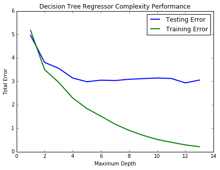

```python
model_complexity(X_train, y_train, X_test, y_test)
```

## Question 9

*From the model complexity graph above, describe the training and testing errors as the max depth increases. Based on your interpretation of the graph, which max depth results in a model that best generalizes the dataset? Why?*

**Answer:** As max depth increases, the model becomes more complex to fit the training data; thus training error continues to decrease as max depth increases. Testing error also decreases as model complexity and fit improves, but only to a certain extent, roughly where max depth = 5, before plateauing off and even slowly inching upward. Thus, a model with max depth = 5 best generalizes the dataset, providing best accuracy in testing set without being overly complicated.

# Model Prediction

In this final section of the project, you will make a prediction on the client's feature set using an optimized model from `fit_model`. *To answer the following questions, it is recommended that you run the code blocks several times and use the median or mean value of the results.*

## Question 10

*Using grid search, what is the optimal `max_depth` parameter for your model? How does this result compare to your intial intuition?*

```python
max_depth = np.zeros(len(range(15)))
sale_price = np.zeros(len(range(15)))

for i in range(15):
    reg = fit_model(housing_features, housing_prices)
    max_depth[i] = reg.best_params_['max_depth']
    sale_price[i] = reg.predict(CLIENT_FEATURES)

max_depth_median = np.median(max_depth)

print "Final model optimal parameters:", "max-depth =", max_depth_median
```

```
Final model optimal parameters: max-depth = 6.0
```

**Answer:** Using grid search, the optimal max_depth for our model is 6, which is very close to my initial intuition of 5 earlier.

## Question 11

*With your parameter-tuned model, what is the best selling price for your client's home? How does this selling price compare to the basic statistics you calculated on the dataset?*

```python
sale_price_median = np.median(sale_price)

print "Predicted value of client's home: {0:.3f}".format(sale_price_median)
```

```
Predicted value of client's home: 20.766
```

**Answer:** With my parameter-tuned model, the best selling price for my client's home is $20,766, slightly below the mean and median housing prices in Boston.

## Question 12 (Final Question):

*In a few sentences, discuss whether you would use this model or not to predict the selling price of future clients' homes in the Greater Boston area.*

**Answer:** I probably would not use this model to predict the selling price of future clients' homes. While this dataset was helpful as a toy analysis, it is very old, dating back to 1970s. Housing prices have appreciated many folds since. Moreover, this model is more appropriate for predicting average house price for a region/precinct, but less so for individual homes as it ignores home-specific factors.